# Swarm Intelligence

## Motivation

Swarm intelligence is a field of science that studies the collective behaviour of decentralized and self-organized systems. Because of the ability to solve complex problems, biological swarms, like ant colonies, bee swarms and school of fishes, are modelled by mathematical algorithms to solve optimization problems.

[figure not shown]

Some problems are still difficult to solve by the current computing techniques:

- Hard-problems
  - NP-complete (travelling salesman)
  - Action-reaction planning (chest)
- Fuzzy problems
  - Intelligent human-machine interaction
  - Natural language
- Dynamic and unpredictable problems
  - Robot automation
  - Business planning
  - Operation Research

### Current Alternatives

Many of the current alternatives are experimental and depends on different computing paradigms. While distributed computing is advanced enough to be largely used (thanks to Hadoop, Spark and other technologies), others are still in research phase.

- DNA Based Computing (chemical computing)
- Quantum Computing (quantum physics)
- Biocomputing (made or mimic biological organisms)-> **Swarm Intelligence**!

## Concepts

Swarm intelligence are a sort of metaheuristics algorithms made to solve optimization problems. The main difference from other algorithms is the biological inspiration, mainly in the social behavior of collective agents. Most observations in nature support the theory that multiple agents, with self interests, work collectively without the need of a centralized command, in cooperation to achieve a desired behavior. Notice that not all population-based algorithms are considered Swarm Intelligence, like genetic algorithms.

Some mechanisms that are used in almost all swarm algorithms and affect directly the algorithm performance.

[figure not shown]

- Exploration and Exploitation: local x global
- Diversity: exploratory capacity, affecting the possibility of finding new solutions
- Communication: how social agents interact to each other
- Evaluation/selection: excluding poor solutions, allowing possible non-differentiable cost functions
- Randomness: stochastic search, to avoid local optimals
- Parallelism: neighborhood/communities

# PSO - Particle Swarm Optimization

PSO is a type of algorithms for swarm intelligence that uses the concept of particles in order to find the optimal value of a set of parameters that maximizes/minimizes a specific cost function. The cost function does not need to be differentiable considering the parameters, but it must be able to evaluate the particle according to its position in a search-space. This space consists of the hyper-dimension derived from all possible values for the set of parameters. This article describes the most common PSO algorithm, which can be found at [1]

The particles are free to move around the search-space (which can be bounded, for example, when some constraints are considered for the possible solution). The algorithm search capacity is directly affected by the particle dynamics: each particle has an associated speed and memory. The swarm has a social memory, consisting of the best position ever found by the swarm (any particle), while each particle has its own memory (its best position ever). These memories are called social and cognitive memory respectively and, together with the particle previous speed, are used to calculated the next speed vector.

## Mathematical Model

Let ${\bf A} \subset \Re^k$ be the search space, in a $k$ dimensional hyperspace, where the particle $\vec{x} = (x_1,...,x_k)$ represents a single point in this space. The algorithm needs an evaluation function, or cost function, that transforms the search space into a one-dimensional space ${\bf Y}$: $$f : {\bf A} \rightarrow {\bf Y} \subseteq \Re,\hspace{1cm} f_i = f(\vec{x}_i) \in {\bf Y}$$
The particle swarm of size $N$ is written as $\textbf{S}(t) = \{ \vec{x}_1(t),...,\vec{x}_N(t) \}$, while its dynamics can be written as the first derivative (speed) of each particle: $\textbf{S'}(t) = \{ \vec{v}_1(t),...,\vec{v}_N(t) \}$. Notice that the particle position and speed are functions of the time $t$, which represents the algorithm iterations. The basic PSO algorithm also requires the definition of the social and cognitive memories:
$\hspace{3cm}\textbf{P} = \{ \vec{p}_1(t), ..., \vec{p}_N(t) \} \hspace{1cm} \rightarrow \hspace{1cm} \text{cognitive}$
$\hspace{3cm}\vec{p}_i(t) = argmin_{t}f(\vec{x}_i(t))$
$\hspace{3cm}\vec{p}_g(t) = argmin_t f(\vec{p}_i(t))\hspace{0.9cm} \rightarrow \hspace{1cm} \text{social}$

The swarm dynamics is update at each iteration of the algorithm. The position of each particle is updated considering its speed vector, while the speed vector itself is updated considering the following equation:
$$\vec{v}_i(t+1) = w\vec{v}_i(t) + c_1R_1(\vec{p}_i(t) - x_i(t)) + c_2R_2(\vec{p}_g(t)-x_i(t))$$
The first term correspond to the current speed, weighted by $w$, called the inertial weight. This term is responsible for allowing a fine search when the current particle is the global best. Otherwise, this particle would not move anymore (the second and third terms would be zero). Normally, the inertial weight changes in time, in order to allow for global and local searches, affecting the swarm diversity:
$$w(t) = W_{up} - (w_{up} - w_{low}) \times \frac{t}{T_{max}}$$
The second term in the speed formula represents the cognitive memory, as it depends on the particle best position ever found. The term $c_1R_1$ adds a randomness search in the direction of $(\vec{p}_i(t) - x_i(t))$. The third term is similar to the second, but it accounts for the social memory. The $R_1$ and $R_2$ terms are random vectors generated from an uniform distribution between 0 and 1 (other random generators can also be used), that multiplies each speed component in the $k$-dimensional space. The $c_1$ and $c_2$ coefficients must be chosen carefully in order to keep the swarm stable.

Another variation of the swarm update algorithm uses the constriction coefficient. This formula was suggested after the studies in [2] and adds a coefficient before updating the speed vector:
$$\vec{v}_i(t+1) = \chi [\vec{v}_i(t) + c_1R_1(\vec{p}_i(t) - x_i(t)) + c_2R_2(\vec{p}_g(t)-x_i(t))]$$
The standard values for the coefficients are: $$\chi = 0.729$$ $$c_1 = 2.05$$ $$c_2 = 2.05$$

### Comments

If the search space is bounded, because of constraints in the solution candidades, por example, then there are two common strategies:

1. Truncate: the solution is truncated and the particle is kept in the limits of the search space
2. Bounce-back: the search space limits work as a mirror, bouncing the particle position back to the interior of the allowed search space.

The speed is also limited in order assist in the swarm stability. If the speed is greater, or lower, than a specific value, than the new speed value is clipped to this specific value. The strategy suggested is to limit the speed considering a fraction of the search space.

## References

1. Parsopoulos, K.E. and Vrahatis, M.N. Particle Swarm Optimization and Intelligence: Advances and Applications. IGI Global. 2010.
2. Clerc, M. and Kennedy, J. The particle swarm - explosion, stability, and convergence in a multidimensional complex space. IEEE Transactions on Evolutionary Computation, vol. 6, pp. 58–73, 2002.

## Algorithm

The following algorithm can be used for PSO. Other sophistications can be added in order to monitor the swarm behavior, update the inertial weight and more.

| Input |  | Parameters: number of particles (N), swarm (S), best positions (P) |
| --- | --- | --- |
| Step 1 |  | Set t = 0 |
| Step 2 |  | Initialize S and set P = S |
| Step 3 |  | Evaluate S and P, defining the global best $\vec{p}_g$ |
| Step 4 |  | while (termination criteria not met) |
| Step 5 |  | Update Swarm (position and speed) |
| Step 6 |  | Evaluate Swarm |
| Step 7 |  | Update memories |
| Step 8 |  | Set t = t + 1 |
| Step 9 |  | End while |
| Step 10 |  | Print best position |

## Simulations

Let's make an arbitrary cost function that operates in a 2D domain, which will be our search space. The custo function values can be displayed as curve lines of different colors. The cost function was chosen to have multiple valleys and peaks, in order to make it hard for the particles do converge to the global optimum. In this scenario, the cost function should be minimized.

### Cost Function

The cost function for this test is made of $ngauss$ Gaussian of 2 dimensions, with negative sign, random mean and variance. This creates a search space with several valleys, in order to illustrate a problem with several local optimal solutions. The idea is just to show the dynamics of the PSO algorithm.

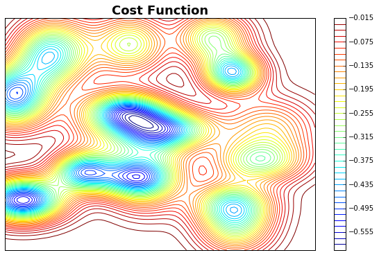

```python
import matplotlib.pyplot as plt
from Swarm.Problem_Gaussian import Problem
%matplotlib inline

ngauss = 20
problem = Problem(ngauss, -1)
plt.figure(figsize=(10,6))
problem.plot(colorbar=True)
plt.title('Cost Function', fontsize=18, fontweight='bold');
```

### Solver

The PSO algorithm solver can be started with the parameters given below. It can be seen that the solver was configured considering the constriction coefficient. The swarm was configured with $nswarm = 20$ particles and with a coefficient of speed limit as $k = 1$. The swarm is randomly initialized across the search space and the social and cognitive memories are set.

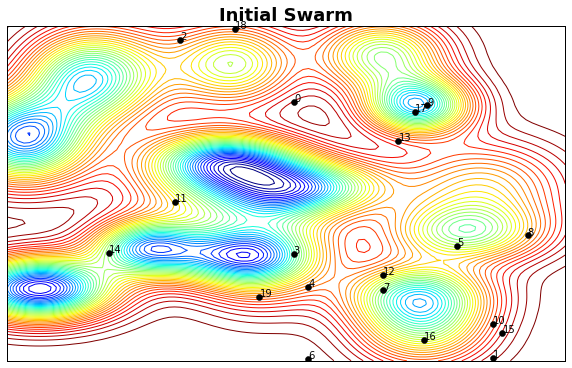

```python
from Swarm import PSO
import numpy as np

swarm_dim = problem.get_problem_dim()
swarm_min, swarm_max = problem.get_solution_limits()
psoArgs = {
    'nswarm': 20,
    'swarm_dim': swarm_dim,
    'epochs': 20,
    'chi': 0.729,
    'rate_cog': 2.05,
    'rate_soc': 2.05,
    'K': 1.0,
    'Wup': 1.5,
    'Wlo': 0.5,
    'Wstep': 200,
    'swarm_max': swarm_max,
    'swarm_min': swarm_min,
    'speed_lim': -1
}

mypso = PSO.PSO(psoArgs)
mypso.cost_func = problem.cost_function
seed = 14
mypso.initialize(seed=seed)
# Initial Swarm
plt.figure(figsize=(10,6))
problem.plot(mypso.swarm)
plt.title('Initial Swarm', fontsize=18, fontweight='bold');
```

The algorithm's exploitation and exploration capacities are the key points for performance, together with the efficiency of information sharing among the swarm. Those aspets give the stochastic search for the global optimal, leading to an efficient optimization algorithm. The following image shows the possible search space for a given particle, at the first iteration of the algorithm. As it can be seen, the randomness of the search is controlled by the cognitive and social coefficients, later weighted by the constriction coefficient. The green dot shows the best position for the swarm, while the blue dots show the possible next positions for the $i$-th particle. The black dots show the position of the swarm particles, together with its index. In this example, only the social component of the speed is considered, but the next particle position also considers the cognitive and inertial components.

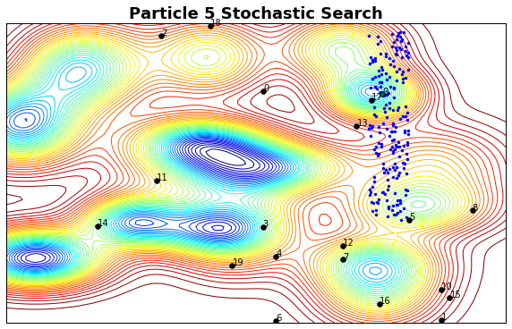

```python
plt.figure(figsize=(10,6))
problem.plot(mypso.swarm)
N = 200
S = np.array(mypso.swarm)
V = np.zeros(S.shape)
R1 = np.random.rand(N, mypso.nswarm, mypso.swarm_dim)
R2 = np.random.rand(N, mypso.nswarm, mypso.swarm_dim)
P = np.array(S)
Pcost = mypso._PSO__cost()
gbest = np.argmin(Pcost)
gbest_cost = Pcost[gbest]
mypso.rate_cog = 0
plt.plot(P[gbest,0],P[gbest,1],'go')
i = 5
for it in range(N):
    V[i] = mypso.chi*(mypso.rate_cog * R1[it][i] *(P[i]    - S[i]) +\
                      mypso.rate_soc * R2[it][i] *(P[gbest]-S[i]))
    nextS = S + V
    plt.plot(nextS[i,0], nextS[i,1],'.b')
plt.axis([mypso.swarm_min, mypso.swarm_max, mypso.swarm_min, mypso.swarm_max])
plt.title('Particle %i Stochastic Search'%(i),  fontsize=18, fontweight='bold');
```

The algorithm time performance is mainly affected by the complexity of the cost function. As one of its advantage, the PSO algorthm does not require the cost function to be differentiable, but it must be possible for the algorithm to evaluate the entire search space.  
After the algorithm training, where all the iterations are executed, or some other stop criteria is met, the swarm configuration can be analyzed. In this 2D problem, the visualization is straight forward. If the swarm is still spread across the searching space, the algorithm convergence and performance can be questioned as, in general, the swarm should shrink around the optimal value found. Although, it is possible that the swarm passed by the optimal value and position along its evolution. If the parameters are well tuned, this should not happen. The left figure shows the final swarm configuration for the 2D problem. It can be seen that the swarm is gathered around the optimal position.  
Another interesting behavior to inspect is the swarm best position evolution, pictured in the centered figure. It can be seen, in our example, that the algorithm was able to walk through peaks and valleys in order to find the global optimal.  
Finally, the right figure shows the final best position found by the algorithm, together with the analytical position of the global optimal for this problem. It can be seen that the two positions are quite close to each other.

```
PSO Training started...
done (0.29 s)
	Time epochs: 0.26 s
	Time cost F: 0.25 s
Analytical Optimal: -0.61, at position (-0.70, 0.60)
Solution found with cost: -0.61, at position (-0.68, 0.59)
```

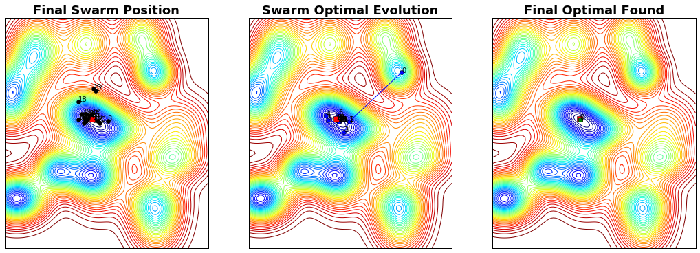

```python
(solution_idx, sol_cost) = mypso.train()
opt = problem.get_optimal()

print('Analytical Optimal: %.2f, at position (%.2f, %.2f)'%(opt[1], opt[0][0], opt[0][1]))
print("Solution found with cost: %.2f, at position (%.2f, %.2f)"%(sol_cost, mypso.swarm_best[-1][0],
                                                                  mypso.swarm_best[-1][1]))

plt.figure(figsize=(18,6))
plt.subplot(1,3,1)
problem.plot(mypso.swarm)
plt.plot(opt[0][0], opt[0][1], 'sr', ms=8)
plt.title('Final Swarm Position', fontsize=18, fontweight='bold')

opt_solution = mypso.swarm_best[-1]
plt.subplot(1,3,2)
problem.plot(mypso.swarm_best, fmt='-ob')
plt.plot(opt[0][0], opt[0][1], 'sr', ms=8)
plt.title('Swarm Optimal Evolution', fontsize=18, fontweight='bold')

plt.subplot(1,3,3)
plt.plot(opt[0][0], opt[0][1], 'sr', ms=8)
problem.plot(mypso.swarm_best[-1], 'sg')
plt.title('Final Optimal Found', fontsize=18, fontweight='bold');
```

As usually shown in optimization algorithms, the best cost function value found at each iteration can be plotted to analyze how difficult it was for the algorithm to evolve (left figure). Considering the PSO algorithm, the swarm diversity is a good measure of how well tuned are the swarm exploitation and exploration capabilities. Ideally, the swarm should be able to exploit the entire search space in order to spot possible local optima positions. Later, as the swarm diversity reduces, as the algorithm iterates, the swarm explores these regions in order to find the global optimum. The swarm inertial weight is suitable for controlling the exploitation / exploration characteristics, as its value reduces in time. The swarm diversity, though, should reduce in time if the swarm is evolving correctly. Other mechanisms to bump up the swarm diversity randomly in time could be used to force the swarm to explore other regions, specially when the algorithm convergence seems to be stalled in a local optimal.

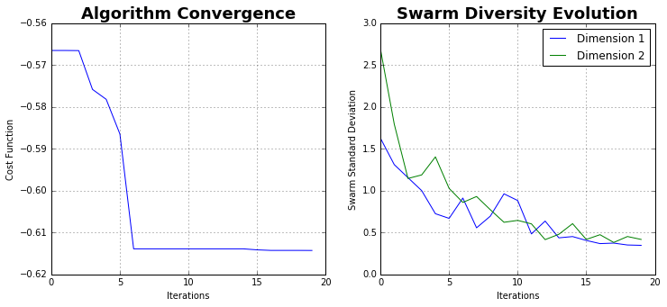

```python
plt.figure(figsize=(12,5))
plt.subplot(1,2,1)
plt.plot(mypso.fitness)
plt.grid()
plt.xlabel('Iterations')
plt.ylabel('Cost Function')
plt.title('Algorithm Convergence', fontsize=18, fontweight='bold')

plt.subplot(1,2,2)
plt.plot(mypso.diversity)
plt.grid()
plt.xlabel('Iterations')
plt.ylabel('Swarm Standard Deviation')
plt.title('Swarm Diversity Evolution', fontsize=18, fontweight='bold')
plt.legend(['Dimension 1', 'Dimension 2'], loc='upper right');
```

Lastly, in order to illustrate the swarm evolution, the swarm position its best position is plotted at each iteration. This animation shows the impact of the parameters in the swarm evolution and is very interesting for understanding the PSO algorithm. The following animations were done considering different configurations of the PSO algorithm, while keeping the same cost function and initial values. The black dots are the particles within the swarm, while the red square is the memory location of the best particle in the swarm.

**Case 1**: Constriction factor with standard coefficients and speed limit. It can be seen that the swarm still moves rather fast, but it is able to find the global optimal.

[figure not shown]

| chi: | 0.729 |
| --- | --- |
| rate_cog: | 2.05 |
| rate_soc: | 2.05 |
| K: | 5.0 |
| Wup: | 0.0 |
| Wlo: | 0.0 |
| Wstep: | 0 |

**Case 2**: Constriction factor with standard coefficients and no speed limit. It can be seen that the swarm moves faster, taking more time to find the global solution, as the particles frequently passes by it.

[figure not shown]

| chi: | 0.729 |
| --- | --- |
| rate_cog: | 2.05 |
| rate_soc: | 2.05 |
| K: | 1.0 |
| Wup: | 0.0 |
| Wlo: | 0.0 |
| Wstep: | 0 |

**Case 3**: Constriction factor with standard coefficients and tighter speed limit. The speed limit helps in a controlled search, although it can limit the exploitation cabapility of the algorithm, which might lead the swarm to a local optimal.

[figure not shown]

| chi: | 0.729 |
| --- | --- |
| rate_cog: | 2.05 |
| rate_soc: | 2.05 |
| K: | 20.0 |
| Wup: | 0.0 |
| Wlo: | 0.0 |
| Wstep: | 0 |

**Case 4**: Inertial weight with standard coefficients and speed limit. It can be seen that, as the inertial weight starts grater than 1, the swarm exploitation is making it move arount the entire search space, regardless of the best position. As this weight is reduced in each iteration, the swarm diversity reduces and the exploration around the best position starts. In the end, the entire swarm moves around this position.

[figure not shown]

| chi: | 0.0 |
| --- | --- |
| rate_cog: | 2.05 |
| rate_soc: | 2.05 |
| K: | 5.0 |
| Wup: | 1.5 |
| Wlo: | 0.5 |
| Wstep: | 20 |

### Final Remarks

This post described some of the motivations and concepts of the Swarm Intelligence, a set of stochastic algorithms used in optimization. These bio-inspired algorithms are one of the most studied subjects due to its performance and unique characteristics. Although there are several swarm algorithms, from school of fishes to the relationship of prey and predator, this post focused on the Particle Swarm algorithms. Inparticular, the basic PSO algorithm was described and used in a simple 2D example. The motivation of this post os just to inspire and to inform the reader about this interesting topic of swarm intelligence and it has no commitment on be used as a scientific or professional reference.